# Risk Factor Analysis

## Outcome Variable

**Outcome Variable:** sstunted

## Predictor Variables

**Intervention Variable:** vagbrth

**Adjustment Set:**

unadjusted

## Stratifying Variables

The analysis was stratified on these variable(s):

- agecat
- studyid

The following strata were considered:

- agecat: 12 months, studyid: ki1000108-CMC-V-BCS-2002
- agecat: 12 months, studyid: ki1000108-IRC
- agecat: 12 months, studyid: ki1017093b-PROVIDE
- agecat: 12 months, studyid: ki1017093c-NIH-Crypto
- agecat: 12 months, studyid: ki1066203-TanzaniaChild2
- agecat: 12 months, studyid: ki1126311-ZVITAMBO
- agecat: 18 months, studyid: ki1000108-CMC-V-BCS-2002
- agecat: 18 months, studyid: ki1000108-IRC
- agecat: 18 months, studyid: ki1017093b-PROVIDE
- agecat: 18 months, studyid: ki1017093c-NIH-Crypto
- agecat: 18 months, studyid: ki1066203-TanzaniaChild2
- agecat: 18 months, studyid: ki1126311-ZVITAMBO
- agecat: 24 months, studyid: ki1000108-CMC-V-BCS-2002
- agecat: 24 months, studyid: ki1000108-IRC
- agecat: 24 months, studyid: ki1017093b-PROVIDE
- agecat: 24 months, studyid: ki1017093c-NIH-Crypto
- agecat: 24 months, studyid: ki1066203-TanzaniaChild2
- agecat: 24 months, studyid: ki1126311-ZVITAMBO
- agecat: 3 months, studyid: ki1000108-CMC-V-BCS-2002
- agecat: 3 months, studyid: ki1000108-IRC
- agecat: 3 months, studyid: ki1017093b-PROVIDE
- agecat: 3 months, studyid: ki1017093c-NIH-Crypto
- agecat: 3 months, studyid: ki1066203-TanzaniaChild2
- agecat: 3 months, studyid: ki1126311-ZVITAMBO
- agecat: 6 months, studyid: ki1000108-CMC-V-BCS-2002
- agecat: 6 months, studyid: ki1000108-IRC
- agecat: 6 months, studyid: ki1017093b-PROVIDE
- agecat: 6 months, studyid: ki1017093c-NIH-Crypto
- agecat: 6 months, studyid: ki1066203-TanzaniaChild2
- agecat: 6 months, studyid: ki1126311-ZVITAMBO
- agecat: 9 months, studyid: ki1000108-CMC-V-BCS-2002
- agecat: 9 months, studyid: ki1000108-IRC
- agecat: 9 months, studyid: ki1017093b-PROVIDE
- agecat: 9 months, studyid: ki1017093c-NIH-Crypto
- agecat: 9 months, studyid: ki1066203-TanzaniaChild2
- agecat: 9 months, studyid: ki1126311-ZVITAMBO
- agecat: Birth, studyid: ki1000108-CMC-V-BCS-2002
- agecat: Birth, studyid: ki1000108-IRC
- agecat: Birth, studyid: ki1017093c-NIH-Crypto
- agecat: Birth, studyid: ki1126311-ZVITAMBO

### Dropped Strata

Some strata were dropped due to rare outcomes:

- agecat: Birth, studyid: ki1000108-CMC-V-BCS-2002
- agecat: Birth, studyid: ki1000108-IRC
- agecat: Birth, studyid: ki1017093c-NIH-Crypto
- agecat: Birth, studyid: ki1126311-ZVITAMBO
- agecat: 3 months, studyid: ki1000108-CMC-V-BCS-2002
- agecat: 3 months, studyid: ki1017093b-PROVIDE
- agecat: 3 months, studyid: ki1066203-TanzaniaChild2
- agecat: 6 months, studyid: ki1000108-CMC-V-BCS-2002
- agecat: 6 months, studyid: ki1017093b-PROVIDE
- agecat: 6 months, studyid: ki1017093c-NIH-Crypto
- agecat: 6 months, studyid: ki1066203-TanzaniaChild2
- agecat: 6 months, studyid: ki1126311-ZVITAMBO
- agecat: 9 months, studyid: ki1000108-CMC-V-BCS-2002
- agecat: 9 months, studyid: ki1017093b-PROVIDE
- agecat: 9 months, studyid: ki1066203-TanzaniaChild2
- agecat: 12 months, studyid: ki1017093b-PROVIDE
- agecat: 12 months, studyid: ki1066203-TanzaniaChild2
- agecat: 18 months, studyid: ki1000108-IRC
- agecat: 18 months, studyid: ki1017093b-PROVIDE
- agecat: 18 months, studyid: ki1066203-TanzaniaChild2
- agecat: 24 months, studyid: ki1000108-IRC
- agecat: 24 months, studyid: ki1017093b-PROVIDE
- agecat: 24 months, studyid: ki1066203-TanzaniaChild2
- agecat: 24 months, studyid: ki1126311-ZVITAMBO

## Methods Detail

We’re interested in the causal parameters $E[Y_a]$ for all values of $a \in \mathcal{A}$. These parameters represent the mean outcome if, possibly contrary to fact, we intervened to set all units to have $A=a$. Under the randomization and positivity assumptions, these are identified by the statistical parameters $\psi_a=E_W[E_{Y|A,W}(Y|A=a,W)]$. In addition, we’re interested in the mean of $Y$, $E[Y]$ under no intervention (the observed mean). We will estimate these parameters by using SuperLearner to fit the relevant likelihood factors – $E_{Y|A,W}(Y|A=a,W)$ and $p(A=a|W)$, and then updating our likelihood fit using a joint TMLE.

For unadjusted analyses ($W=\{\}$), initial likelihoods were estimated using Lrnr_glm to estimate the simple $E(Y|A)$ and Lrnr_mean to estimate $p(A)$. For adjusted analyses, a small library containing Lrnr_glmnet, Lrnr_xgboost, and Lrnr_mean was used.

Having estimated these parameters, we will then use the delta method to estimate relative risks and attributable risks relative to a prespecified baseline level of $A$.

# Results Detail

## Results Plots

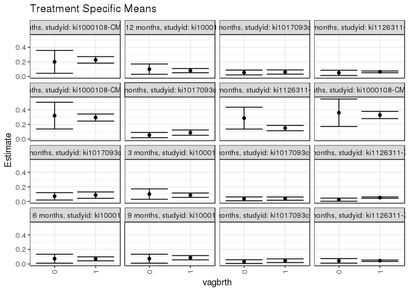

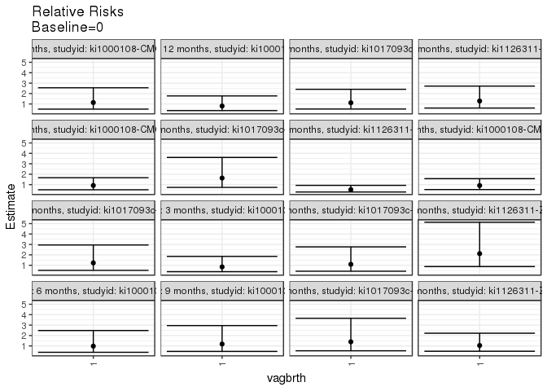

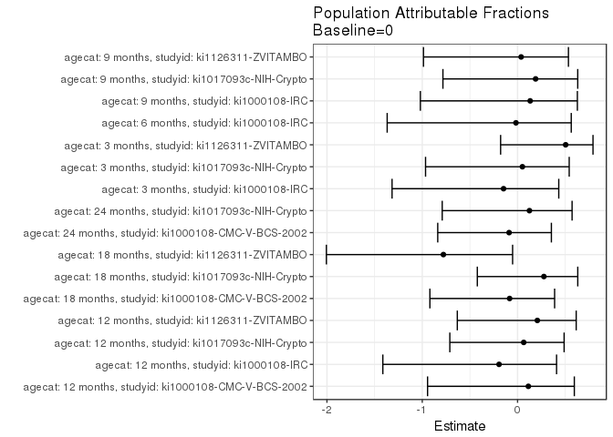

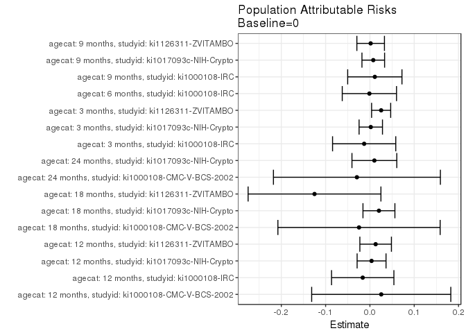

## Data Summary

| agecat | studyid | A | n | nA | nAY0 | nAY1 |
| --- | --- | --- | --- | --- | --- | --- |
| Birth | ki1000108-CMC-V-BCS-2002 | 0 | 90 | 11 | 10 | 1 |
| Birth | ki1000108-CMC-V-BCS-2002 | 1 | 90 | 79 | 77 | 2 |
| Birth | ki1000108-IRC | 0 | 388 | 68 | 67 | 1 |
| Birth | ki1000108-IRC | 1 | 388 | 320 | 305 | 15 |
| Birth | ki1017093b-PROVIDE | 0 | 0 | 0 | 0 | 0 |
| Birth | ki1017093b-PROVIDE | 1 | 0 | 0 | 0 | 0 |
| Birth | ki1017093c-NIH-Crypto | 0 | 19 | 1 | 1 | 0 |
| Birth | ki1017093c-NIH-Crypto | 1 | 19 | 18 | 18 | 0 |
| Birth | ki1066203-TanzaniaChild2 | 0 | 0 | 0 | 0 | 0 |
| Birth | ki1066203-TanzaniaChild2 | 1 | 0 | 0 | 0 | 0 |
| Birth | ki1126311-ZVITAMBO | 0 | 3418 | 288 | 284 | 4 |
| Birth | ki1126311-ZVITAMBO | 1 | 3418 | 3130 | 3025 | 105 |
| 3 months | ki1000108-CMC-V-BCS-2002 | 0 | 362 | 25 | 23 | 2 |
| 3 months | ki1000108-CMC-V-BCS-2002 | 1 | 362 | 337 | 306 | 31 |
| 3 months | ki1000108-IRC | 0 | 407 | 69 | 62 | 7 |
| 3 months | ki1000108-IRC | 1 | 407 | 338 | 309 | 29 |
| 3 months | ki1017093b-PROVIDE | 0 | 168 | 38 | 36 | 2 |
| 3 months | ki1017093b-PROVIDE | 1 | 168 | 130 | 127 | 3 |
| 3 months | ki1017093c-NIH-Crypto | 0 | 471 | 193 | 186 | 7 |
| 3 months | ki1017093c-NIH-Crypto | 1 | 471 | 278 | 267 | 11 |
| 3 months | ki1066203-TanzaniaChild2 | 0 | 573 | 43 | 43 | 0 |
| 3 months | ki1066203-TanzaniaChild2 | 1 | 573 | 530 | 520 | 10 |
| 3 months | ki1126311-ZVITAMBO | 0 | 2251 | 201 | 196 | 5 |
| 3 months | ki1126311-ZVITAMBO | 1 | 2251 | 2050 | 1942 | 108 |
| 6 months | ki1000108-CMC-V-BCS-2002 | 0 | 369 | 25 | 23 | 2 |
| 6 months | ki1000108-CMC-V-BCS-2002 | 1 | 369 | 344 | 304 | 40 |
| 6 months | ki1000108-IRC | 0 | 407 | 69 | 64 | 5 |
| 6 months | ki1000108-IRC | 1 | 407 | 338 | 314 | 24 |
| 6 months | ki1017093b-PROVIDE | 0 | 153 | 32 | 30 | 2 |
| 6 months | ki1017093b-PROVIDE | 1 | 153 | 121 | 117 | 4 |

[output cut: 54 more lines]

## Results Table

### Parameter: TSM

| agecat | studyid | intervention_level | baseline_level | estimate | ci_lower | ci_upper |
| --- | --- | --- | --- | --- | --- | --- |
| 3 months | ki1000108-IRC | 0 | NA | 0.1014493 | 0.0301223 | 0.1727762 |
| 3 months | ki1000108-IRC | 1 | NA | 0.0857988 | 0.0559047 | 0.1156929 |
| 3 months | ki1017093c-NIH-Crypto | 0 | NA | 0.0362694 | 0.0098649 | 0.0626740 |
| 3 months | ki1017093c-NIH-Crypto | 1 | NA | 0.0395683 | 0.0166283 | 0.0625084 |
| 3 months | ki1126311-ZVITAMBO | 0 | NA | 0.0248756 | 0.0033397 | 0.0464115 |
| 3 months | ki1126311-ZVITAMBO | 1 | NA | 0.0526829 | 0.0430102 | 0.0623557 |
| 6 months | ki1000108-IRC | 0 | NA | 0.0724638 | 0.0112169 | 0.1337106 |
| 6 months | ki1000108-IRC | 1 | NA | 0.0710059 | 0.0435916 | 0.0984202 |
| 9 months | ki1000108-IRC | 0 | NA | 0.0724638 | 0.0112169 | 0.1337106 |
| 9 months | ki1000108-IRC | 1 | NA | 0.0857988 | 0.0559047 | 0.1156929 |
| 9 months | ki1017093c-NIH-Crypto | 0 | NA | 0.0324324 | 0.0068774 | 0.0579874 |
| 9 months | ki1017093c-NIH-Crypto | 1 | NA | 0.0452830 | 0.0202212 | 0.0703449 |
| 9 months | ki1126311-ZVITAMBO | 0 | NA | 0.0429448 | 0.0118141 | 0.0740755 |
| 9 months | ki1126311-ZVITAMBO | 1 | NA | 0.0447678 | 0.0351774 | 0.0543581 |
| 12 months | ki1000108-CMC-V-BCS-2002 | 0 | NA | 0.2000000 | 0.0429894 | 0.3570106 |
| 12 months | ki1000108-CMC-V-BCS-2002 | 1 | NA | 0.2274052 | 0.1829863 | 0.2718242 |
| 12 months | ki1000108-IRC | 0 | NA | 0.1000000 | 0.0296351 | 0.1703649 |
| 12 months | ki1000108-IRC | 1 | NA | 0.0803571 | 0.0512543 | 0.1094600 |
| 12 months | ki1017093c-NIH-Crypto | 0 | NA | 0.0540541 | 0.0214334 | 0.0866747 |
| 12 months | ki1017093c-NIH-Crypto | 1 | NA | 0.0603774 | 0.0316681 | 0.0890866 |
| 12 months | ki1126311-ZVITAMBO | 0 | NA | 0.0492958 | 0.0136785 | 0.0849130 |
| 12 months | ki1126311-ZVITAMBO | 1 | NA | 0.0633894 | 0.0512399 | 0.0755389 |
| 18 months | ki1000108-CMC-V-BCS-2002 | 0 | NA | 0.3200000 | 0.1368964 | 0.5031036 |
| 18 months | ki1000108-CMC-V-BCS-2002 | 1 | NA | 0.2936047 | 0.2454139 | 0.3417954 |
| 18 months | ki1017093c-NIH-Crypto | 0 | NA | 0.0533333 | 0.0173275 | 0.0893391 |
| 18 months | ki1017093c-NIH-Crypto | 1 | NA | 0.0869565 | 0.0504935 | 0.1234196 |
| 18 months | ki1126311-ZVITAMBO | 0 | NA | 0.2857143 | 0.1358710 | 0.4355576 |
| 18 months | ki1126311-ZVITAMBO | 1 | NA | 0.1492147 | 0.1134418 | 0.1849875 |
| 24 months | ki1000108-CMC-V-BCS-2002 | 0 | NA | 0.3600000 | 0.1715900 | 0.5484100 |
| 24 months | ki1000108-CMC-V-BCS-2002 | 1 | NA | 0.3285303 | 0.2790458 | 0.3780147 |
| 24 months | ki1017093c-NIH-Crypto | 0 | NA | 0.0707071 | 0.0201159 | 0.1212983 |
| 24 months | ki1017093c-NIH-Crypto | 1 | NA | 0.0869565 | 0.0433483 | 0.1305648 |

### Parameter: E(Y)

| agecat | studyid | intervention_level | baseline_level | estimate | ci_lower | ci_upper |
| --- | --- | --- | --- | --- | --- | --- |
| 3 months | ki1000108-IRC | NA | NA | 0.0884521 | 0.0878809 | 0.0890233 |
| 3 months | ki1017093c-NIH-Crypto | NA | NA | 0.0382166 | 0.0380699 | 0.0383632 |
| 3 months | ki1126311-ZVITAMBO | NA | NA | 0.0501999 | 0.0498723 | 0.0505276 |
| 6 months | ki1000108-IRC | NA | NA | 0.0712531 | 0.0711999 | 0.0713063 |
| 9 months | ki1000108-IRC | NA | NA | 0.0835381 | 0.0830514 | 0.0840248 |
| 9 months | ki1017093c-NIH-Crypto | NA | NA | 0.0400000 | 0.0394152 | 0.0405848 |
| 9 months | ki1126311-ZVITAMBO | NA | NA | 0.0446154 | 0.0445930 | 0.0446378 |
| 12 months | ki1000108-CMC-V-BCS-2002 | NA | NA | 0.2255435 | 0.2248379 | 0.2262490 |
| 12 months | ki1000108-IRC | NA | NA | 0.0837438 | 0.0830212 | 0.0844665 |
| 12 months | ki1017093c-NIH-Crypto | NA | NA | 0.0577778 | 0.0574900 | 0.0580656 |
| 12 months | ki1126311-ZVITAMBO | NA | NA | 0.0622038 | 0.0620171 | 0.0623905 |
| 18 months | ki1000108-CMC-V-BCS-2002 | NA | NA | 0.2953930 | 0.2947152 | 0.2960707 |
| 18 months | ki1017093c-NIH-Crypto | NA | NA | 0.0736842 | 0.0720296 | 0.0753388 |
| 18 months | ki1126311-ZVITAMBO | NA | NA | 0.1606715 | 0.1570343 | 0.1643086 |
| 24 months | ki1000108-CMC-V-BCS-2002 | NA | NA | 0.3306452 | 0.3298434 | 0.3314469 |
| 24 months | ki1017093c-NIH-Crypto | NA | NA | 0.0807692 | 0.0798083 | 0.0817302 |

### Parameter: RR

| agecat | studyid | intervention_level | baseline_level | estimate | ci_lower | ci_upper |
| --- | --- | --- | --- | --- | --- | --- |
| 3 months | ki1000108-IRC | 1 | 0 | 0.8457312 | 0.3858792 | 1.8535883 |
| 3 months | ki1017093c-NIH-Crypto | 1 | 0 | 1.0909558 | 0.4301585 | 2.7668513 |
| 3 months | ki1126311-ZVITAMBO | 1 | 0 | 2.1178537 | 0.8740691 | 5.1315210 |
| 6 months | ki1000108-IRC | 1 | 0 | 0.9798817 | 0.3869206 | 2.4815635 |
| 9 months | ki1000108-IRC | 1 | 0 | 1.1840237 | 0.4745983 | 2.9538917 |
| 9 months | ki1017093c-NIH-Crypto | 1 | 0 | 1.3962264 | 0.5330604 | 3.6570870 |
| 9 months | ki1126311-ZVITAMBO | 1 | 0 | 1.0424494 | 0.4895250 | 2.2199087 |
| 12 months | ki1000108-CMC-V-BCS-2002 | 1 | 0 | 1.1370262 | 0.5063274 | 2.5533453 |
| 12 months | ki1000108-IRC | 1 | 0 | 0.8035714 | 0.3641925 | 1.7730376 |
| 12 months | ki1017093c-NIH-Crypto | 1 | 0 | 1.1169811 | 0.5180557 | 2.4083255 |
| 12 months | ki1126311-ZVITAMBO | 1 | 0 | 1.2858991 | 0.6089297 | 2.7154801 |
| 18 months | ki1000108-CMC-V-BCS-2002 | 1 | 0 | 0.9175145 | 0.5059279 | 1.6639386 |
| 18 months | ki1017093c-NIH-Crypto | 1 | 0 | 1.6304348 | 0.7364680 | 3.6095494 |
| 18 months | ki1126311-ZVITAMBO | 1 | 0 | 0.5222513 | 0.2933889 | 0.9296414 |
| 24 months | ki1000108-CMC-V-BCS-2002 | 1 | 0 | 0.9125841 | 0.5293636 | 1.5732280 |
| 24 months | ki1017093c-NIH-Crypto | 1 | 0 | 1.2298137 | 0.5133025 | 2.9464916 |

### Parameter: PAR

| agecat | studyid | intervention_level | baseline_level | estimate | ci_lower | ci_upper |
| --- | --- | --- | --- | --- | --- | --- |
| 3 months | ki1000108-IRC | 0 | NA | -0.0129972 | -0.0843264 | 0.0583320 |
| 3 months | ki1017093c-NIH-Crypto | 0 | NA | 0.0019471 | -0.0244578 | 0.0283521 |
| 3 months | ki1126311-ZVITAMBO | 0 | NA | 0.0253243 | 0.0037859 | 0.0468627 |
| 6 months | ki1000108-IRC | 0 | NA | -0.0012107 | -0.0624576 | 0.0600362 |
| 9 months | ki1000108-IRC | 0 | NA | 0.0110743 | -0.0501745 | 0.0723231 |
| 9 months | ki1017093c-NIH-Crypto | 0 | NA | 0.0075676 | -0.0179941 | 0.0331292 |
| 9 months | ki1126311-ZVITAMBO | 0 | NA | 0.0016706 | -0.0294601 | 0.0328013 |
| 12 months | ki1000108-CMC-V-BCS-2002 | 0 | NA | 0.0255435 | -0.1314687 | 0.1825557 |
| 12 months | ki1000108-IRC | 0 | NA | -0.0162562 | -0.0866247 | 0.0541124 |
| 12 months | ki1017093c-NIH-Crypto | 0 | NA | 0.0037237 | -0.0288982 | 0.0363456 |
| 12 months | ki1126311-ZVITAMBO | 0 | NA | 0.0129080 | -0.0227097 | 0.0485257 |
| 18 months | ki1000108-CMC-V-BCS-2002 | 0 | NA | -0.0246070 | -0.2077119 | 0.1584978 |
| 18 months | ki1017093c-NIH-Crypto | 0 | NA | 0.0203509 | -0.0156929 | 0.0563947 |
| 18 months | ki1126311-ZVITAMBO | 0 | NA | -0.1250428 | -0.2749303 | 0.0248446 |
| 24 months | ki1000108-CMC-V-BCS-2002 | 0 | NA | -0.0293548 | -0.2177665 | 0.1590568 |
| 24 months | ki1017093c-NIH-Crypto | 0 | NA | 0.0100622 | -0.0405382 | 0.0606625 |

### Parameter: PAF

| agecat | studyid | intervention_level | baseline_level | estimate | ci_lower | ci_upper |
| --- | --- | --- | --- | --- | --- | --- |
| 3 months | ki1000108-IRC | 0 | NA | -0.1469404 | -1.3168471 | 0.4322144 |
| 3 months | ki1017093c-NIH-Crypto | 0 | NA | 0.0509499 | -0.9654637 | 0.5417386 |
| 3 months | ki1126311-ZVITAMBO | 0 | NA | 0.5044688 | -0.1777947 | 0.7915162 |
| 6 months | ki1000108-IRC | 0 | NA | -0.0169915 | -1.3680229 | 0.5632341 |
| 9 months | ki1000108-IRC | 0 | NA | 0.1325661 | -1.0198241 | 0.6274717 |
| 9 months | ki1017093c-NIH-Crypto | 0 | NA | 0.1891892 | -0.7831129 | 0.6313110 |
| 9 months | ki1126311-ZVITAMBO | 0 | NA | 0.0374444 | -0.9872228 | 0.5337648 |
| 12 months | ki1000108-CMC-V-BCS-2002 | 0 | NA | 0.1132530 | -0.9442253 | 0.5955612 |
| 12 months | ki1000108-IRC | 0 | NA | -0.1941176 | -1.4135750 | 0.4092096 |
| 12 months | ki1017093c-NIH-Crypto | 0 | NA | 0.0644491 | -0.7106662 | 0.4883540 |
| 12 months | ki1126311-ZVITAMBO | 0 | NA | 0.2075117 | -0.6322340 | 0.6152282 |
| 18 months | ki1000108-CMC-V-BCS-2002 | 0 | NA | -0.0833028 | -0.9197937 | 0.3887130 |
| 18 months | ki1017093c-NIH-Crypto | 0 | NA | 0.2761905 | -0.4222715 | 0.6316454 |
| 18 months | ki1126311-ZVITAMBO | 0 | NA | -0.7782516 | -2.0058806 | -0.0519974 |
| 24 months | ki1000108-CMC-V-BCS-2002 | 0 | NA | -0.0887805 | -0.8375347 | 0.3548732 |
| 24 months | ki1017093c-NIH-Crypto | 0 | NA | 0.1245791 | -0.7906033 | 0.5720092 |